# Business Travel Pattern and Expenses of L&F Company

## by Thomas Ying

## Investigation Overview

This report will be divided into two parts. In the first part, travel pattern of L&F will be discussed. We will mainly focus on travel frequency of each operating group and the related features. The second part is about travel expenses. We will discuss about L&F's spending on flying and how the operating groups spent those money in 2019.

## Dataset Overview

This dataset is prepared by L&F, which can be divided into 3 parts by the function of features. From the first column to the fifth column(Division) are the info of the travelers; the sixth column(Invoice_No) to the seventeenth column(Airline_Code) are the info of the travel product; the eighteenth column(Original_Fare) to the last column are the info about price of the product. The fisrt two part of the dataset are all string and datetime, then all price variables are continuous numerical data.

The dataset contained approximately 31,000 travel application record of L&F in 2019. Since we just need data of purchasing flight tickets, columns and rows of Visa and Miscellaneous Charge were removed, plus we only want to analyse the trips which were occured only in 2019, some data points also got removed. Finally we have 28776 travel application record for this investigation.

## Part 1 - Travel Pattern

## Travel Frequency by Operating Group, Region and Trip Purpose

SCS2 is the group which recorded the most travel record in 2019 with over 4000 times, following by LF Asia Direct which traveled around 4000 times. Staffs from SCS3 and LF Logistics both traveled over 3000 times in 2019. SCS4, LF Products, SCS1, LF Europe and Cobalt Fashion all recorded over 1000 times of business trips. All the operating groups mentioned above compose the main influence of travel in L&F.

For Country/Region, L&F as a Hong Kong based cooperation, it is no wonder that most of the travlers are from Hong Kong. The following region, Shanghai, Shenzhen in China, and India, are well known of manufacturing so it is not surprised that they have far more travelers than other regions.

For Trip Purpose, L&F as a trading and supply chain company, customer visit, quality control and supplier visit are naturally the main purpose of business travel. These three purposes recorded over or neraly 5000 counts.

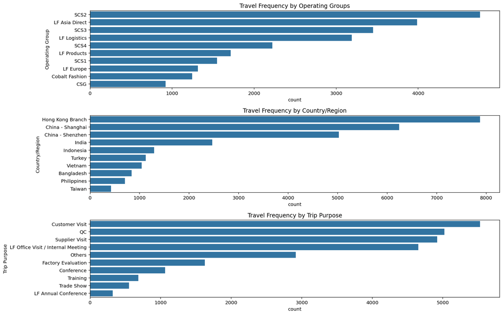

## Popular Destinations and Carriers

Again, L&F as a Hog Kong based company, Hong Kong(HKG) is undoubtedly the most frequent destination among all. In five of the following destination, four of them are from China including Shanghai(SHA&PVG), Shenzhen(SZX) and Guangzhou (CAN). Since we know most travelers are from Hong Kong, Shanghai and Shenzhen, it is not surprised that the most frequent destination are Hong Kong and cities from China. One special case is Ho Chi Minh City(SGN), which is at the fourth position, is only behind Hong Kong and Shanghai, while not many travelers are from Vietnam. Also notice that almost all the popular destination are Asian cities, only London(LHR) and New York(JFK) are the exceptions.

Cathay Pacific(CX) and Dragonair(KA)(not exsiting anymore tho) are two of the biggest airlines in Hong Kong so no wonder they are top on the list, following by China Eastern(MU) and China Southern(CZ). Turkish Airlines(TK) at the fifth and Vietnam Airlines at the sixth but these two have almost the same count. If TK is not counted, American Airlines(AA) is the only carrier which is from outside of Asia.

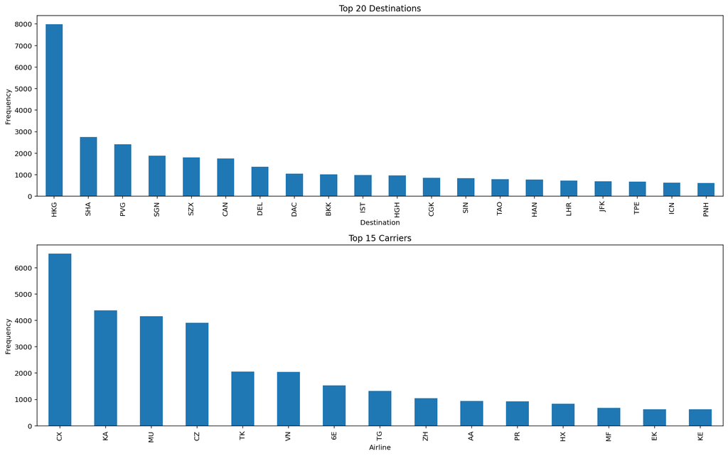

## Popular Destinations by Operating Group

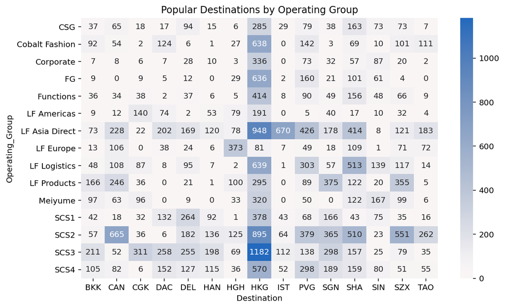

## Favored Carriers by Operating Group

Cathay Pacific(CX) or Drangonair(KA) were not as expected that being the most common carrier for all the operating groups. No doubt that CX and KA were popular options for every operating group but many of them prefere other carriers even more. SCS2 traveled with China Southern(CZ) the most with almost 1400 times, following by China Eastern(MU). For LF Logistics, the most common carrier is Philippine Airlines(PR). In fact, almost all the tickets of PR are issued from LF Logistics. LF Asia Direct traveled a lot(1408 times) with Turkish Airlines, which match the result that the group always traveled to Istanbul.

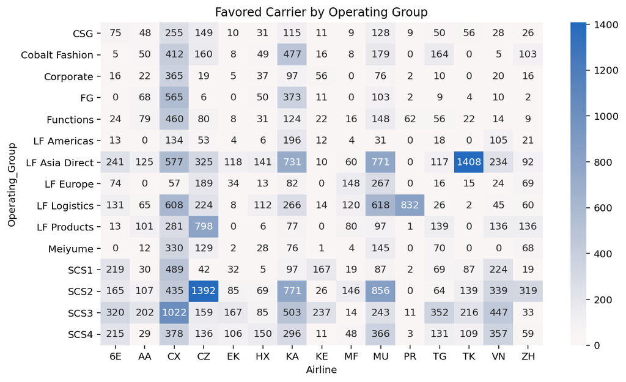

## Part 2 - Travel Expenses

## Distribustion of Flight Expenses

Net fare in the dataset take on a very large range of values, from less than 1USD at the lowest, to about 30,000USD at the highest. When plotted on a logarithmic scale, the Net Fare distribution looks a normal distribution, with the peak between 100USD and 220USD. Distribution keeps going downward after 220USD, but after 2,000USD it raise a bit again becoming a tiny hill between 3,000USD and 5,000USD. Guess that is the price range of business class.

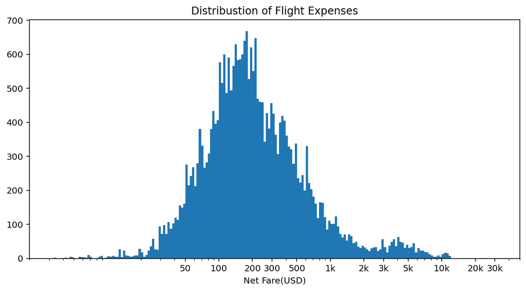

## Distribution of Premium (Overpay)

Premium in the dataset also take on a very large range of values, from about -700USD (means money was saved) at the lowest, to about 14,000USD at the highest. Distribution of Premium with symmetric log scale is unimodal, with the peak in between 30USD and 100USD but with two small cliff in around 40USD and 50USD. There are two outliers in 12,000USD and 14,500USD, but for the case of Premium, it is normal because some staffs from the board level can simply go overpaying as they wish.

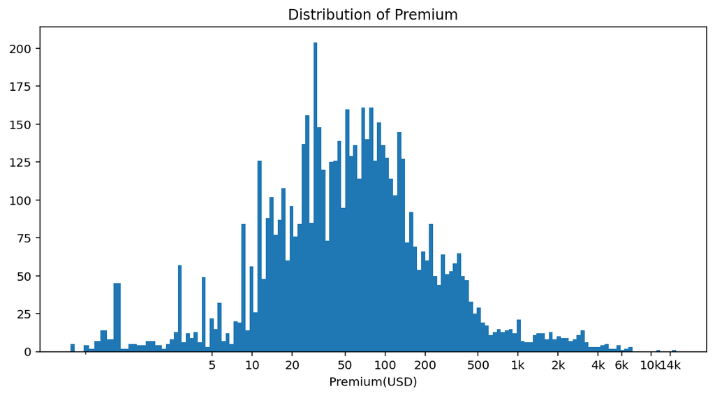

## Flight Expenses, Discount and Premium by Operating Groups

Although SCS2 travel most frequently, LF Asia Direct is the most spending operating group with spending 1,600,000USD on business travel on 2019. Notice that FG is the fifth spending group and it is even not in the top 10 when counting frequency of travel.

FG was the champion of overpaying. The amazing thing is, actually their frequency of travle was low, they did spend a lot, but didn't get much discount, and they always spent a lot more than the lower logical fare. LF Asia Direct, SCS2 and LF Logistics also overpay quite a lot in 2019, however, considering they flew very frequently, they are more acceptable than the case of FG.

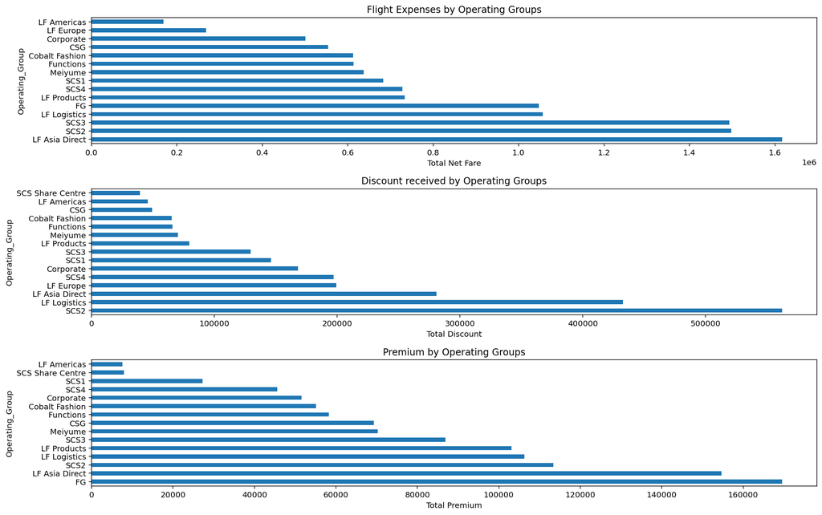

## Flight Expenses by Destinations and Carriers

Hong Kong(HKG) is the destination where the travelers mostly spent on. Some US cities can be found on this list such as New York(JFK), Los Angeles(LAX) and Chicago(ORD). Of course the main reason is that most of the flights to these cities are long haul so price of tickets would be high, but from the result we could know which cities are popular outside of Asia.

For airline, it's normal that CX is on the top but I am still impressed by the expenses as the number is few times more than other carriers. And from the chart we know that American Airlines(AA) and United Airlines(UA) are two of the most frequent used carriers in US.

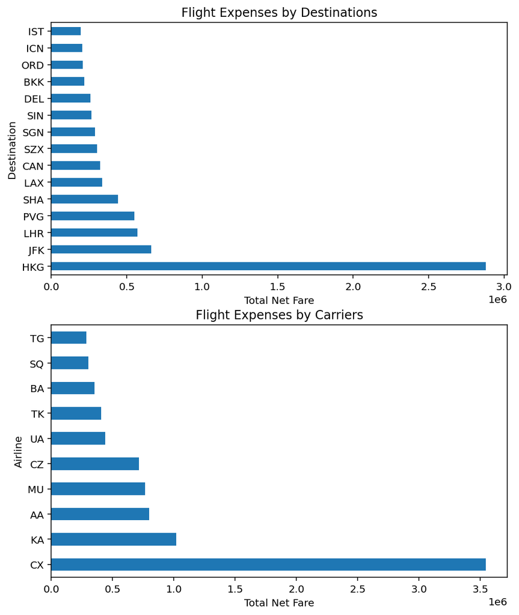

## Flight Expenses vs. Discount with Selected Operating Groups

Discount has a positive correlation with Net Fare but it is weak, which implies that purchasing a higher price ticket might help to get a higher discount but not always the case. From the colors of the scatter plot, we know that the positive correlation is mostly come from SCS2(green), and partly from LF Logistics(blue) and LF Asia Direct(yellow). Dots of FG(purple) almost form a vertical line which stands on 0 discount.

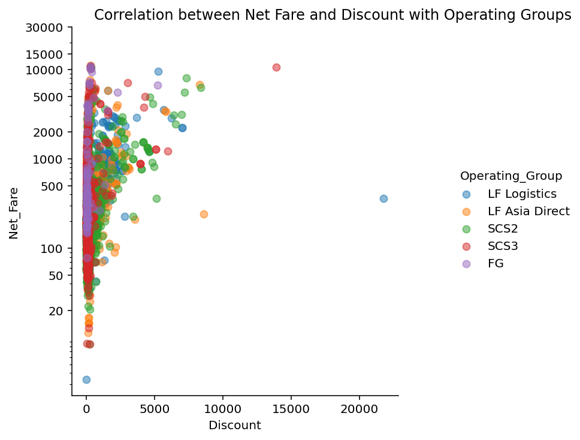

Premium has a strong positive correlation with Net Fare. FG(purple) contribute this the most, then LF Asia Direct(yellow) and SCS3(red) after that. Looking at the area of over 2000 Net Fare and 1000 Premium, you will find that the dots are mostly purple, yellow and red ,which means when the net fare rose, premium of these operating groups rose faster and was more synchronous with net fare than the other operating groups.

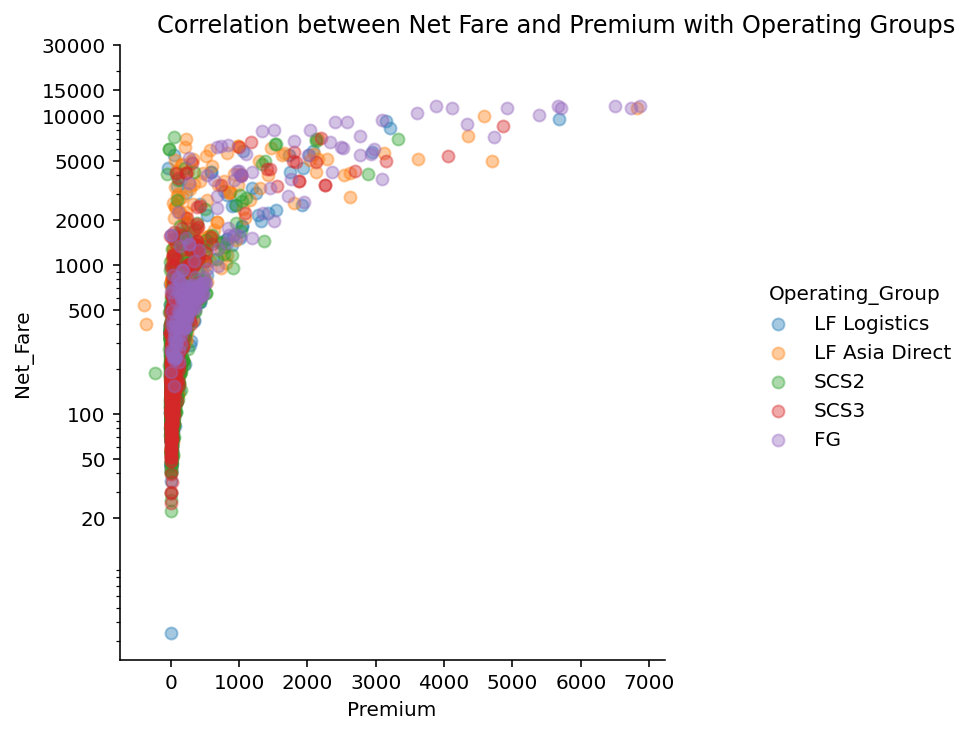

## Travel Expenses by Selected Operating Groups and Destinations

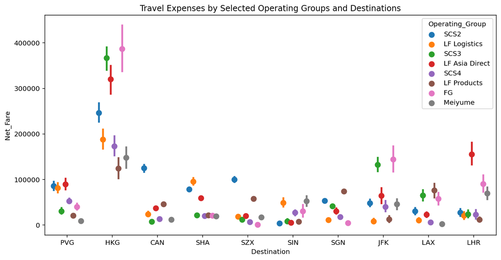

## Flight Expenses by Selected Operating Groups and Carriers

FG(purple) is a big fan of CX, it spent far more than other operating groups on the carrier. If oyu check the heatmap in the last section, FG is only the forth frequent traveler of CX among all groups so you can imagine how high is the average spending of them on CX. On the other hand, from the point plot above we learned that SCS3 and LF Asia Direct are two of the operating groups which have higher proportion of long haul travel and now we have more details about it. For expenses on CX, SCS3(green) and LF Asia Direct(red) were only after FG (CX for long haul flight and KA for short haul flight in Hong Kong). They were also top 2 in spending on AA. LF Asia Direct had very high spending on TK(flight to Istanbul consider as long haul) and was also the top spending group of British Airways(BA).

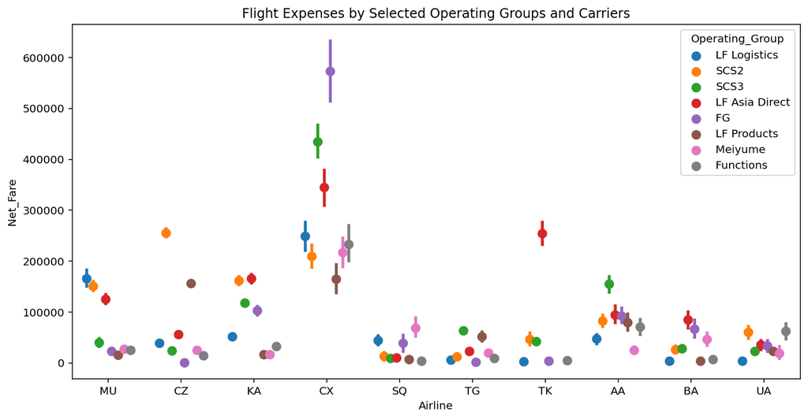

## Selected Operating Group's Monthly Short/Long Haul Flight Expenses

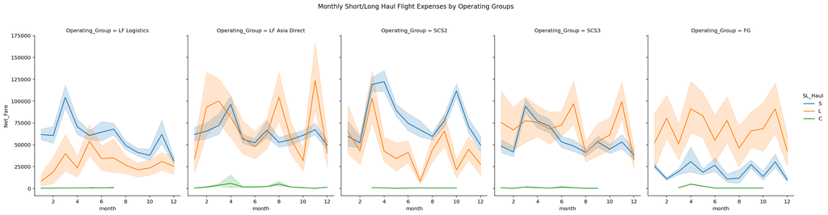